# Einleitung

7. Oktober 2017

## Zeitplan

- **09:45** Einführung in R mit Übungsaufgaben.
- **11:00** Datenaufbereitung mit Übungsaufgaben.
- **12:00** Mittagspause.
- **13:00** Datenverarbeitung.
- **14:00** Datenvisualisierung mit Übungsaufgaben.
- **16:20** Statistik.

## Literatur

- [R for Data Science](http://r4ds.had.co.nz/): Sollte unbedingt jeder lesen, der/die mit R Datenanalyse machen möchte.
- [ggplot2: Elegant Graphics for Data Analysis](https://www.amazon.de/ggplot2-Elegant-Graphics-Data-Analysis/dp/331924275X/ref=sr_1_1?ie=UTF8&qid=1505585504&sr=8-1&keywords=ggplot2): Gibt einen wesentlich detaillierteren Einblick, wie die Datenvisualisierung mit ggplot2 funktioniert. Nicht unbedingt notwendig, aber dennoch sehr empfehlenswert!
- [Reproducible Research with R and R Studio](https://www.amazon.de/Reproducible-Research-Studio-Second-Chapman/dp/1498715370/ref=sr_1_1?s=books-intl-de&ie=UTF8&qid=1505585637&sr=1-1&keywords=reproducible+research+with+r): Möchte man ernsthafte bzw. umfangreichere Datenanalyse mit R betreiben, ist dieses Buch ajf lesenswert.
- [Handbook of Biological Statistics](http://www.biostathandbook.com/): Gibt einen sehr guten Überblick über Statistik in der Biologie und viele nützliche Informationen.
- http://rcompanion.org/handbook/ baut praktisch auf dem vorherigen Buch auf und zeigt die Anwendung in R.

## Literatur II

- [Statistics in a Nutshell](https://www.amazon.de/Statistics-Nutshell-OReilly-Sarah-Boslaugh/dp/1449316824/ref=sr_1_1?ie=UTF8&qid=1506966944&sr=8-1&keywords=statistics+in+a+nutshell): Sehr gutes Statistik-Buch, das alle grundlegenden Kenntnisse für Nicht-Mathematiker verständlich erklärt. Absolut lesenswert.
- [Hands-On Programming with R](https://www.amazon.de/Hands-Programming-Write-Functions-Simulations/dp/1449359019): Für etwas ambitioniertere Personen, die bereits etwas Erfahrung mit R haben. Hilft dabei, mehr aus R herauszuholen. Programmieren klingt schlimmer als es gibt, mit etwas Fleiß kann das jeder.
- [R Packages](https://www.amazon.de/R-Packages-Hadley-Wickham/dp/1491910593/ref=pd_sim_14_6?_encoding=UTF8&psc=1&refRID=5PXK1NE2B1ZTPNE4FR7X): Wer selbstgeschriebene Funktionen immer wieder braucht, kann diese in ein eigenes Paket packen und so für sich selbst und u.U. auch andere verfügbar machen.

## RStudio, eine IDE

## ID… Was?

RStudio ist ein Editor, der speziell für die Nutzung mit R entwickelt wurde und einige nützliche Features besitzt:

- Syntax-Highlighting
- Code-Vervollständigung
- Code-Faltung
- Installation von neuen Paketen
- Projektverwaltung
- KOSTENLOS

## Die Oberfläche

[figure not shown]

## R, eine erste Einführung

## Die Konsole

In die Konsole können wir Befehle eintippen und mit Enter an R schicken. Wir bekommen dann das Ergebnis zurück.

```r
1 + 1
```

```
## [1] 2
```

Man kann selbstverständlich auch komplexere Ausdrücke eingeben.

```r
15 * 31 - 4^3
```

```
## [1] 401
```

Einen Taschenrechner hat aber schon jeder.

## Objekte

```r
a <- 15
b <- 2

a * b
```

```
## [1] 30
```

```r
c <- a * b

c
```

```
## [1] 30
```

## Vektoren

Datensätze bestehen aber selten aus nur einer Zahl!

```r
a <- c(1, 2, 3, 4, 5, 6, 7, 8, 9, 10)

a
```

```
##  [1]  1  2  3  4  5  6  7  8  9 10
```

Dies nennt man in R einen Vektor. Jede Zahl stellt ein Element dieses Vektors dar.

Mit Vektoren kann man ebenfalls rechnen. Elementeweise:

```r
a + 1
```

```
##  [1]  2  3  4  5  6  7  8  9 10 11
```

Oder man verrechnet zwei Vektoren miteinander. Der kürzere wird recycelt.

```r
b <- c(0, 2)

a * b
```

```
##  [1]  0  4  0  8  0 12  0 16  0 20
```

## Datentypen

Datensätze bestehen ja nicht immer nur aus numerischen Werten, sondern auch aus Wörtern.

```r
d <- c("Grün", "Blau", "Gelb", "Rot")
```

Text bezeichnet der Informatiker als **Character Strings**.

## Character

Character verhalten sich anders als numerische Werte.

```r
"1" + "2"
```

```
## Error in "1" + "2": nicht-numerisches Argument für binären Operator
```

Ein Vektor kann immer nur ganz genau **einen** Datentyp haben, also niemals Zahlen und Character gleichzeitig.

```r
c(1, "A")
```

```
## [1] "1" "A"
```

Wir werden später sehen, wie man diese Einschränkung umgeht.

## Datentypen

Interessiert einen der Datentyp eines Objekts, kann man dies mit `typeof()` herausfinden:

```r
typeof(c(1, 2))
```

```
## [1] "double"
```

```r
typeof(c("A", "B"))
```

```
## [1] "character"
```

```r
typeof(c(TRUE, FALSE))
```

```
## [1] "logical"
```

## Weitere Datentypen

Neben numersichen Daten und Character Strings gibt es noch sog. **Booleans** oder auch **Logische Werte**.

- Diese nehmen einen der beiden Werte TRUE oder FALSE bzw. 1 oder 0 an.
- Diese logischen Werten sind später interessant, wenn man z.B. das Vorgehen an Bedingungen knüpft.
- Mit Logicals kann man aus einem Vektor bestimmte Werte extrahieren.

## Subsetting

Man kann Elemente eines Vektors mit `[]` und der Positionsangabe bekommen.

```r
Measurement <- c("Wildtype", "Unknown", "Ebony", "Wildtype", "Ebony", "Ebony", "Ebony")

Measurement[2]
```

```
## [1] "Unknown"
```

```r
Measurement[c(2, 5, 7)]
```

```
## [1] "Unknown" "Ebony"   "Ebony"
```

## Logical Subsetting

Alternativ kann man auch Logicals nutzen, um bestimmte Werte eines Vektors zu bekommen.

```r
Measurement
```

```
## [1] "Wildtype" "Unknown"  "Ebony"    "Wildtype" "Ebony"    "Ebony"
## [7] "Ebony"
```

```r
Measurement[c(TRUE, FALSE)]
```

```
## [1] "Wildtype" "Ebony"    "Ebony"    "Ebony"
```

Logical Subsetting ist vor allem dann interessant, wenn man nicht ein festes Muster, sondern eine Bedingung vorgibt.

```r
Measurement
```

```
## [1] "Wildtype" "Unknown"  "Ebony"    "Wildtype" "Ebony"    "Ebony"
## [7] "Ebony"
```

```r
Measurement == "Wildtype"
```

```
## [1]  TRUE FALSE FALSE  TRUE FALSE FALSE FALSE
```

```r
Measurement[Measurement == "Wildtype"]
```

```
## [1] "Wildtype" "Wildtype"
```

## Listen

Und wenn ich zwei Datentypen in einem Datensatz habe?

```r
Liste <- list(c("A", "B", "C"), c(1, 2, 3))

Liste
```

```
## [[1]]
## [1] "A" "B" "C"
##
## [[2]]
## [1] 1 2 3
```

```r
typeof(Liste)
```

```
## [1] "list"
```

Listen können Vektoren mit verschiedenen Datentypen beinhalten.

Und sogar andere Listen!

## Dataframes

Aber es wäre ja viel intuitiver, wenn man Daten in Form einer Tabelle speichern könnte!

```r
Tabelle <- data.frame("Spalte 1" = c("A", "B", "C"),
                      "Spalte 2" = c(1, 2, 3))

Tabelle
```

```
##   Spalte.1 Spalte.2
## 1        A        1
## 2        B        2
## 3        C        3
```

Dataframes sind Rs Art und Weise, Tabellen darzustellen!

Im Grunde handelt es sich um eine Liste, in der die Vektoren als Spalten dargestellt werden!

```r
typeof(Tabelle)
```

```
## [1] "list"
```

## Kurzen Zusammenfassung

- Datenreihen werden in R durch Vektoren dargestellt.
- Jeder Vektor kann genau einen Datentyp haben.
- Mehrere Datentypen können in einer Liste untergebracht werden.
- Eine besondere Form der Liste ist der Dataframe.
- Dataframes stellen Datentabellen dar. Jede Spalte ist ein Vektor mit einem Datentyp.

**ALLES, was in R existiert, ist ein Objekt.**

## Funktionen

Wir haben nun ein Format, um Daten zu speichern. Aber was machen wir mit diesen Daten?

```r
a <- c(1, 2, 3, 4, 5, 6, 7, 8, 9, 10)

mean(a)
```

```
## [1] 5.5
```

```r
sd(a)
```

```
## [1] 3.02765
```

Jede Funktion hat einen Namen und Argumente, die in Klammern dahinter stehen und durch Kommata getrennt sind.

```r
function_name(argument_1 = value1, argument_2 = value2, ...)
```

Das ist analog zu Funktionen aus der Mathematik.

\[ f(x) = x^2 \] \[ f(x, y) = x^2 + y \]

## Die Argumente

Jedes Argument hat einen Namen, eine Position und i.d.R. einen Standardwert.

```r
help(mean)

mean(x = dataset, trim = 0, na.rm = TRUE)

mean(dataset, 0, TRUE)

mean(dataset, na.rm = TRUE)
```

**ALLES, was in R passiert, ist ein Funktionsaufruf.**

Funktionen können einfache Dinge tun, wie z.B. den Mittelwert berechnen.

Man kann aber auch verschiedene Funktionen kombinieren, um beliebig komplexe Abläufe zu erstellen.

Funktionen müssen nicht zwangsweisen Text oder Zahlen zurückgeben. Grafiken sind ebenso möglich.

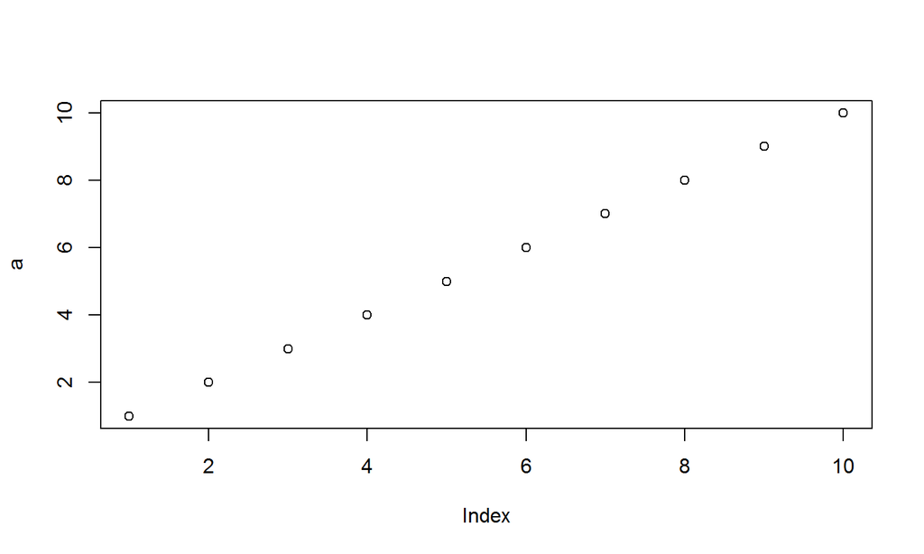

```r
plot(a)
```

## Die Idee

Die Idee ist, dass wir ein oder mehrere Objekte (Daten) haben. Auf diese Objekte wenden wir sukzessive Funktionen an, bis wir das gewünschte Ergebnis haben.

## factors - Kategorische Variablen

Nicht-numerische Variablen in der Datenanalyse sind i.d.R. kategorische Variablen mit einer begrenzten Anzahl an möglichen Ausprägungen. Diese werden in R durch `factors` dargestellt.

- `factors` sind in R als Integer repräsentiert, welche zusätzlich ein *Label*, also einen Namen haben.
- Die Kategorien, die ein `factor` haben kann, werden `levels` genannt. Dies ist also im Prinzip ein anderes Wort für **Kategorie**.

## Vorteile von factors

`factors` haben in einigen Situationen Vorteile gegenüber *Character-Strings*:

- Da `factors` in R als Zahlen repräsentiert werden, haben sie eine Reihenfolge und werden nicht zwangsläufig alphabetisch sortiert.
- Eine Kategorische Variable hat mehrere mögliche Ausprägungen (`levels`). Allerdings kommen in einer realen Messung nicht zwangsläufig auch alle Kategorien vor. Dennoch möchte man manchmal auch fehlende Kategorien in einem Diagramm darstellen.

`factors` werden durch `factor(x, levels)` erstellt.

```r
BodyColours <- c("Wildtype", "Yellow", "Ebony")

Measurement
```

```
## [1] "Wildtype" "Unknown"  "Ebony"    "Wildtype" "Ebony"    "Ebony"
## [7] "Ebony"
```

```r
Measurement <- factor(x = Measurement, levels = BodyColours)
Measurement
```

```
## [1] Wildtype <NA>     Ebony    Wildtype Ebony    Ebony    Ebony
## Levels: Wildtype Yellow Ebony
```

```r
table(Measurement, useNA = "always")
```

```
## Measurement
## Wildtype   Yellow    Ebony     <NA>
##        2        0        4        1
```

```r
typeof(Measurement)
```

```
## [1] "integer"
```

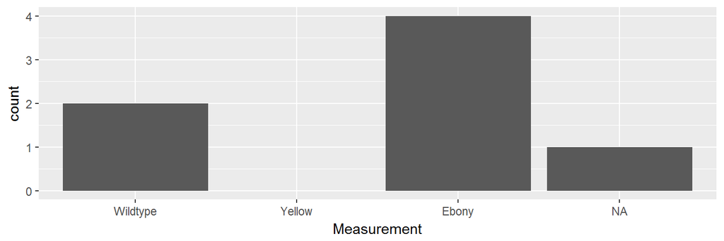